# Risk Factor Analysis

## Outcome Variable

**Outcome Variable:** pers_wast

## Predictor Variables

**Intervention Variable:** month

**Adjustment Set:**

unadjusted

## Stratifying Variables

The analysis was stratified on these variable(s):

- agecat
- studyid
- country

## Data Summary

| agecat | studyid | country | month | pers_wast | n_cell | n |
| --- | --- | --- | --- | --- | --- | --- |
| 0-24 months | ki0047075b-MAL-ED | BANGLADESH | 1 | 0 | 20 | 248 |
| 0-24 months | ki0047075b-MAL-ED | BANGLADESH | 1 | 1 | 0 | 248 |
| 0-24 months | ki0047075b-MAL-ED | BANGLADESH | 2 | 0 | 19 | 248 |
| 0-24 months | ki0047075b-MAL-ED | BANGLADESH | 2 | 1 | 1 | 248 |
| 0-24 months | ki0047075b-MAL-ED | BANGLADESH | 3 | 0 | 25 | 248 |
| 0-24 months | ki0047075b-MAL-ED | BANGLADESH | 3 | 1 | 1 | 248 |
| 0-24 months | ki0047075b-MAL-ED | BANGLADESH | 4 | 0 | 21 | 248 |
| 0-24 months | ki0047075b-MAL-ED | BANGLADESH | 4 | 1 | 1 | 248 |
| 0-24 months | ki0047075b-MAL-ED | BANGLADESH | 5 | 0 | 19 | 248 |
| 0-24 months | ki0047075b-MAL-ED | BANGLADESH | 5 | 1 | 2 | 248 |
| 0-24 months | ki0047075b-MAL-ED | BANGLADESH | 6 | 0 | 7 | 248 |
| 0-24 months | ki0047075b-MAL-ED | BANGLADESH | 6 | 1 | 1 | 248 |
| 0-24 months | ki0047075b-MAL-ED | BANGLADESH | 7 | 0 | 19 | 248 |
| 0-24 months | ki0047075b-MAL-ED | BANGLADESH | 7 | 1 | 1 | 248 |
| 0-24 months | ki0047075b-MAL-ED | BANGLADESH | 8 | 0 | 24 | 248 |
| 0-24 months | ki0047075b-MAL-ED | BANGLADESH | 8 | 1 | 0 | 248 |
| 0-24 months | ki0047075b-MAL-ED | BANGLADESH | 9 | 0 | 20 | 248 |
| 0-24 months | ki0047075b-MAL-ED | BANGLADESH | 9 | 1 | 2 | 248 |
| 0-24 months | ki0047075b-MAL-ED | BANGLADESH | 10 | 0 | 20 | 248 |
| 0-24 months | ki0047075b-MAL-ED | BANGLADESH | 10 | 1 | 2 | 248 |
| 0-24 months | ki0047075b-MAL-ED | BANGLADESH | 11 | 0 | 15 | 248 |
| 0-24 months | ki0047075b-MAL-ED | BANGLADESH | 11 | 1 | 1 | 248 |
| 0-24 months | ki0047075b-MAL-ED | BANGLADESH | 12 | 0 | 26 | 248 |
| 0-24 months | ki0047075b-MAL-ED | BANGLADESH | 12 | 1 | 1 | 248 |
| 0-24 months | ki0047075b-MAL-ED | BRAZIL | 1 | 0 | 13 | 217 |
| 0-24 months | ki0047075b-MAL-ED | BRAZIL | 1 | 1 | 0 | 217 |
| 0-24 months | ki0047075b-MAL-ED | BRAZIL | 2 | 0 | 26 | 217 |
| 0-24 months | ki0047075b-MAL-ED | BRAZIL | 2 | 1 | 0 | 217 |
| 0-24 months | ki0047075b-MAL-ED | BRAZIL | 3 | 0 | 18 | 217 |
| 0-24 months | ki0047075b-MAL-ED | BRAZIL | 3 | 1 | 0 | 217 |

[output cut: 1674 more lines]

The following strata were considered:

- agecat: 0-24 months, studyid: ki0047075b-MAL-ED, country: BANGLADESH
- agecat: 0-24 months, studyid: ki0047075b-MAL-ED, country: BRAZIL
- agecat: 0-24 months, studyid: ki0047075b-MAL-ED, country: INDIA
- agecat: 0-24 months, studyid: ki0047075b-MAL-ED, country: NEPAL
- agecat: 0-24 months, studyid: ki0047075b-MAL-ED, country: PERU
- agecat: 0-24 months, studyid: ki0047075b-MAL-ED, country: SOUTH AFRICA
- agecat: 0-24 months, studyid: ki0047075b-MAL-ED, country: TANZANIA, UNITED REPUBLIC OF
- agecat: 0-24 months, studyid: ki1000108-CMC-V-BCS-2002, country: INDIA
- agecat: 0-24 months, studyid: ki1000108-IRC, country: INDIA
- agecat: 0-24 months, studyid: ki1000109-EE, country: PAKISTAN
- agecat: 0-24 months, studyid: ki1000109-ResPak, country: PAKISTAN
- agecat: 0-24 months, studyid: ki1000304b-SAS-CompFeed, country: INDIA
- agecat: 0-24 months, studyid: ki1000304b-SAS-FoodSuppl, country: INDIA
- agecat: 0-24 months, studyid: ki1017093-NIH-Birth, country: BANGLADESH
- agecat: 0-24 months, studyid: ki1066203-TanzaniaChild2, country: TANZANIA, UNITED REPUBLIC OF
- agecat: 0-24 months, studyid: ki1112895-Guatemala BSC, country: GUATEMALA
- agecat: 0-24 months, studyid: ki1112895-iLiNS-Zinc, country: BURKINA FASO
- agecat: 0-24 months, studyid: ki1113344-GMS-Nepal, country: NEPAL
- agecat: 0-24 months, studyid: ki1114097-CMIN, country: BANGLADESH
- agecat: 0-24 months, studyid: ki1114097-CMIN, country: BRAZIL
- agecat: 0-24 months, studyid: ki1114097-CMIN, country: GUINEA-BISSAU
- agecat: 0-24 months, studyid: ki1114097-CMIN, country: PERU
- agecat: 0-24 months, studyid: ki1114097-CONTENT, country: PERU
- agecat: 0-24 months, studyid: ki1119695-PROBIT, country: BELARUS
- agecat: 0-24 months, studyid: ki1126311-ZVITAMBO, country: ZIMBABWE
- agecat: 0-24 months, studyid: ki1148112-LCNI-5, country: MALAWI
- agecat: 0-24 months, studyid: kiGH5241-JiVitA-3, country: BANGLADESH
- agecat: 0-24 months, studyid: kiGH5241-JiVitA-4, country: BANGLADESH
- agecat: 0-6 months, studyid: ki0047075b-MAL-ED, country: BANGLADESH
- agecat: 0-6 months, studyid: ki0047075b-MAL-ED, country: BRAZIL
- agecat: 0-6 months, studyid: ki0047075b-MAL-ED, country: INDIA
- agecat: 0-6 months, studyid: ki0047075b-MAL-ED, country: NEPAL
- agecat: 0-6 months, studyid: ki0047075b-MAL-ED, country: PERU
- agecat: 0-6 months, studyid: ki0047075b-MAL-ED, country: SOUTH AFRICA
- agecat: 0-6 months, studyid: ki0047075b-MAL-ED, country: TANZANIA, UNITED REPUBLIC OF
- agecat: 0-6 months, studyid: ki1000108-CMC-V-BCS-2002, country: INDIA
- agecat: 0-6 months, studyid: ki1000108-IRC, country: INDIA
- agecat: 0-6 months, studyid: ki1000109-EE, country: PAKISTAN
- agecat: 0-6 months, studyid: ki1000109-ResPak, country: PAKISTAN
- agecat: 0-6 months, studyid: ki1066203-TanzaniaChild2, country: TANZANIA, UNITED REPUBLIC OF
- agecat: 0-6 months, studyid: ki1113344-GMS-Nepal, country: NEPAL
- agecat: 0-6 months, studyid: ki1114097-CMIN, country: BANGLADESH
- agecat: 0-6 months, studyid: ki1114097-CMIN, country: PERU
- agecat: 0-6 months, studyid: ki1114097-CONTENT, country: PERU
- agecat: 6-24 months, studyid: ki0047075b-MAL-ED, country: BANGLADESH
- agecat: 6-24 months, studyid: ki0047075b-MAL-ED, country: BRAZIL
- agecat: 6-24 months, studyid: ki0047075b-MAL-ED, country: INDIA
- agecat: 6-24 months, studyid: ki0047075b-MAL-ED, country: NEPAL
- agecat: 6-24 months, studyid: ki0047075b-MAL-ED, country: PERU
- agecat: 6-24 months, studyid: ki0047075b-MAL-ED, country: SOUTH AFRICA
- agecat: 6-24 months, studyid: ki0047075b-MAL-ED, country: TANZANIA, UNITED REPUBLIC OF
- agecat: 6-24 months, studyid: ki1000108-CMC-V-BCS-2002, country: INDIA
- agecat: 6-24 months, studyid: ki1000108-IRC, country: INDIA
- agecat: 6-24 months, studyid: ki1000109-EE, country: PAKISTAN
- agecat: 6-24 months, studyid: ki1000109-ResPak, country: PAKISTAN
- agecat: 6-24 months, studyid: ki1000304b-SAS-CompFeed, country: INDIA
- agecat: 6-24 months, studyid: ki1000304b-SAS-FoodSuppl, country: INDIA
- agecat: 6-24 months, studyid: ki1017093-NIH-Birth, country: BANGLADESH
- agecat: 6-24 months, studyid: ki1066203-TanzaniaChild2, country: TANZANIA, UNITED REPUBLIC OF
- agecat: 6-24 months, studyid: ki1112895-Guatemala BSC, country: GUATEMALA
- agecat: 6-24 months, studyid: ki1112895-iLiNS-Zinc, country: BURKINA FASO
- agecat: 6-24 months, studyid: ki1113344-GMS-Nepal, country: NEPAL
- agecat: 6-24 months, studyid: ki1114097-CMIN, country: BANGLADESH
- agecat: 6-24 months, studyid: ki1114097-CMIN, country: BRAZIL
- agecat: 6-24 months, studyid: ki1114097-CMIN, country: GUINEA-BISSAU
- agecat: 6-24 months, studyid: ki1114097-CMIN, country: PERU
- agecat: 6-24 months, studyid: ki1114097-CONTENT, country: PERU
- agecat: 6-24 months, studyid: ki1119695-PROBIT, country: BELARUS
- agecat: 6-24 months, studyid: ki1126311-ZVITAMBO, country: ZIMBABWE
- agecat: 6-24 months, studyid: ki1148112-LCNI-5, country: MALAWI
- agecat: 6-24 months, studyid: kiGH5241-JiVitA-4, country: BANGLADESH

### Dropped Strata

Some strata were dropped due to rare outcomes:

- agecat: 0-24 months, studyid: ki0047075b-MAL-ED, country: BANGLADESH
- agecat: 0-24 months, studyid: ki0047075b-MAL-ED, country: BRAZIL
- agecat: 0-24 months, studyid: ki0047075b-MAL-ED, country: INDIA
- agecat: 0-24 months, studyid: ki0047075b-MAL-ED, country: NEPAL
- agecat: 0-24 months, studyid: ki0047075b-MAL-ED, country: PERU
- agecat: 0-24 months, studyid: ki0047075b-MAL-ED, country: SOUTH AFRICA
- agecat: 0-24 months, studyid: ki0047075b-MAL-ED, country: TANZANIA, UNITED REPUBLIC OF
- agecat: 0-24 months, studyid: ki1000108-CMC-V-BCS-2002, country: INDIA
- agecat: 0-24 months, studyid: ki1000108-IRC, country: INDIA
- agecat: 0-24 months, studyid: ki1000109-EE, country: PAKISTAN
- agecat: 0-24 months, studyid: ki1000109-ResPak, country: PAKISTAN
- agecat: 0-24 months, studyid: ki1000304b-SAS-CompFeed, country: INDIA
- agecat: 0-24 months, studyid: ki1000304b-SAS-FoodSuppl, country: INDIA
- agecat: 0-24 months, studyid: ki1017093-NIH-Birth, country: BANGLADESH
- agecat: 0-24 months, studyid: ki1066203-TanzaniaChild2, country: TANZANIA, UNITED REPUBLIC OF
- agecat: 0-24 months, studyid: ki1112895-Guatemala BSC, country: GUATEMALA
- agecat: 0-24 months, studyid: ki1113344-GMS-Nepal, country: NEPAL
- agecat: 0-24 months, studyid: ki1114097-CMIN, country: BANGLADESH
- agecat: 0-24 months, studyid: ki1114097-CMIN, country: BRAZIL
- agecat: 0-24 months, studyid: ki1114097-CMIN, country: GUINEA-BISSAU
- agecat: 0-24 months, studyid: ki1114097-CMIN, country: PERU
- agecat: 0-24 months, studyid: ki1114097-CONTENT, country: PERU
- agecat: 0-24 months, studyid: ki1148112-LCNI-5, country: MALAWI
- agecat: 0-6 months, studyid: ki0047075b-MAL-ED, country: BANGLADESH
- agecat: 0-6 months, studyid: ki0047075b-MAL-ED, country: BRAZIL
- agecat: 0-6 months, studyid: ki0047075b-MAL-ED, country: INDIA
- agecat: 0-6 months, studyid: ki0047075b-MAL-ED, country: NEPAL
- agecat: 0-6 months, studyid: ki0047075b-MAL-ED, country: PERU
- agecat: 0-6 months, studyid: ki0047075b-MAL-ED, country: SOUTH AFRICA
- agecat: 0-6 months, studyid: ki0047075b-MAL-ED, country: TANZANIA, UNITED REPUBLIC OF
- agecat: 0-6 months, studyid: ki1000108-CMC-V-BCS-2002, country: INDIA
- agecat: 0-6 months, studyid: ki1000108-IRC, country: INDIA
- agecat: 0-6 months, studyid: ki1000109-EE, country: PAKISTAN
- agecat: 0-6 months, studyid: ki1000109-ResPak, country: PAKISTAN
- agecat: 0-6 months, studyid: ki1066203-TanzaniaChild2, country: TANZANIA, UNITED REPUBLIC OF
- agecat: 0-6 months, studyid: ki1113344-GMS-Nepal, country: NEPAL
- agecat: 0-6 months, studyid: ki1114097-CMIN, country: BANGLADESH
- agecat: 0-6 months, studyid: ki1114097-CMIN, country: PERU
- agecat: 0-6 months, studyid: ki1114097-CONTENT, country: PERU
- agecat: 6-24 months, studyid: ki0047075b-MAL-ED, country: BANGLADESH
- agecat: 6-24 months, studyid: ki0047075b-MAL-ED, country: BRAZIL
- agecat: 6-24 months, studyid: ki0047075b-MAL-ED, country: INDIA
- agecat: 6-24 months, studyid: ki0047075b-MAL-ED, country: NEPAL
- agecat: 6-24 months, studyid: ki0047075b-MAL-ED, country: PERU
- agecat: 6-24 months, studyid: ki0047075b-MAL-ED, country: SOUTH AFRICA
- agecat: 6-24 months, studyid: ki0047075b-MAL-ED, country: TANZANIA, UNITED REPUBLIC OF
- agecat: 6-24 months, studyid: ki1000108-CMC-V-BCS-2002, country: INDIA
- agecat: 6-24 months, studyid: ki1000108-IRC, country: INDIA
- agecat: 6-24 months, studyid: ki1000109-EE, country: PAKISTAN
- agecat: 6-24 months, studyid: ki1000109-ResPak, country: PAKISTAN
- agecat: 6-24 months, studyid: ki1000304b-SAS-FoodSuppl, country: INDIA
- agecat: 6-24 months, studyid: ki1017093-NIH-Birth, country: BANGLADESH
- agecat: 6-24 months, studyid: ki1066203-TanzaniaChild2, country: TANZANIA, UNITED REPUBLIC OF
- agecat: 6-24 months, studyid: ki1112895-Guatemala BSC, country: GUATEMALA
- agecat: 6-24 months, studyid: ki1113344-GMS-Nepal, country: NEPAL
- agecat: 6-24 months, studyid: ki1114097-CMIN, country: BANGLADESH
- agecat: 6-24 months, studyid: ki1114097-CMIN, country: BRAZIL
- agecat: 6-24 months, studyid: ki1114097-CMIN, country: GUINEA-BISSAU
- agecat: 6-24 months, studyid: ki1114097-CMIN, country: PERU
- agecat: 6-24 months, studyid: ki1114097-CONTENT, country: PERU
- agecat: 6-24 months, studyid: ki1119695-PROBIT, country: BELARUS
- agecat: 6-24 months, studyid: ki1126311-ZVITAMBO, country: ZIMBABWE
- agecat: 6-24 months, studyid: ki1148112-LCNI-5, country: MALAWI

## Methods Detail

We’re interested in the causal parameters $E[Y_a]$ for all values of $a \in \mathcal{A}$. These parameters represent the mean outcome if, possibly contrary to fact, we intervened to set all units to have $A=a$. Under the randomization and positivity assumptions, these are identified by the statistical parameters $\psi_a=E_W[E_{Y|A,W}(Y|A=a,W)]$. In addition, we’re interested in the mean of $Y$, $E[Y]$ under no intervention (the observed mean). We will estimate these parameters by using SuperLearner to fit the relevant likelihood factors – $E_{Y|A,W}(Y|A=a,W)$ and $p(A=a|W)$, and then updating our likelihood fit using a joint TMLE.

For unadjusted analyses ($W=\{\}$), initial likelihoods were estimated using Lrnr_glm to estimate the simple $E(Y|A)$ and Lrnr_mean to estimate $p(A)$. For adjusted analyses, a small library containing Lrnr_glmnet, Lrnr_xgboost, and Lrnr_mean was used.

Having estimated these parameters, we will then use the delta method to estimate relative risks and attributable risks relative to a prespecified baseline level of $A$.

# Results Detail

## Results Plots

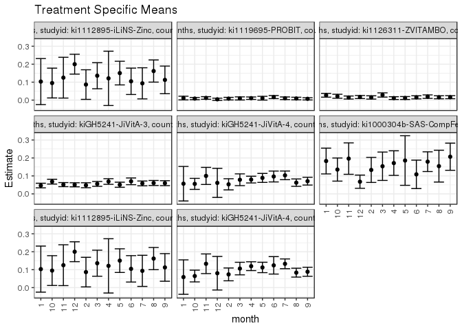

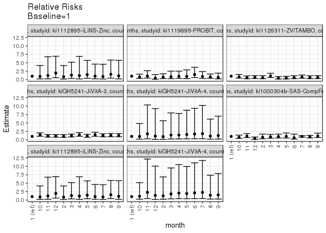

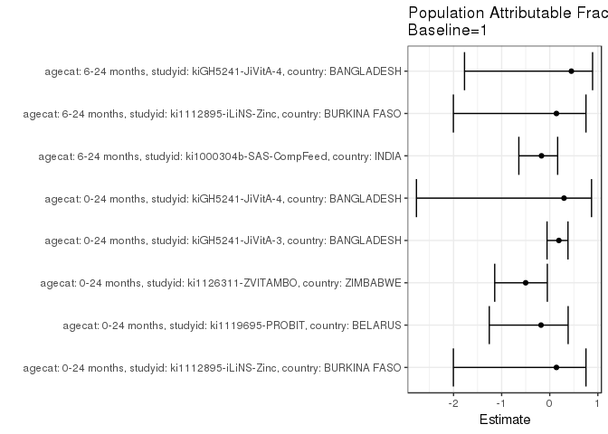

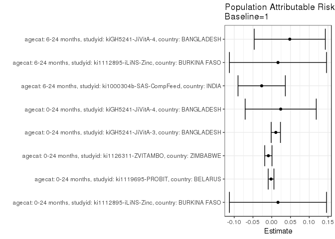

## Results Table

### Parameter: TSM

| agecat | studyid | country | intervention_level | baseline_level | estimate | ci_lower | ci_upper |
| --- | --- | --- | --- | --- | --- | --- | --- |
| 0-24 months | ki1112895-iLiNS-Zinc | BURKINA FASO | 1 | NA | 0.1031746 | -0.0251156 | 0.2314648 |
| 0-24 months | ki1112895-iLiNS-Zinc | BURKINA FASO | 2 | NA | 0.0865385 | 0.0041394 | 0.1689376 |
| 0-24 months | ki1112895-iLiNS-Zinc | BURKINA FASO | 3 | NA | 0.1359223 | 0.0632883 | 0.2085564 |
| 0-24 months | ki1112895-iLiNS-Zinc | BURKINA FASO | 4 | NA | 0.1212121 | -0.0299747 | 0.2723989 |
| 0-24 months | ki1112895-iLiNS-Zinc | BURKINA FASO | 5 | NA | 0.1504425 | 0.0845608 | 0.2163241 |
| 0-24 months | ki1112895-iLiNS-Zinc | BURKINA FASO | 6 | NA | 0.1047120 | 0.0312439 | 0.1781802 |
| 0-24 months | ki1112895-iLiNS-Zinc | BURKINA FASO | 7 | NA | 0.0934579 | 0.0067666 | 0.1801493 |
| 0-24 months | ki1112895-iLiNS-Zinc | BURKINA FASO | 8 | NA | 0.1619048 | 0.1001995 | 0.2236101 |
| 0-24 months | ki1112895-iLiNS-Zinc | BURKINA FASO | 9 | NA | 0.1125828 | 0.0356469 | 0.1895187 |
| 0-24 months | ki1112895-iLiNS-Zinc | BURKINA FASO | 10 | NA | 0.0950000 | 0.0120340 | 0.1779660 |
| 0-24 months | ki1112895-iLiNS-Zinc | BURKINA FASO | 11 | NA | 0.1250000 | 0.0113568 | 0.2386432 |
| 0-24 months | ki1112895-iLiNS-Zinc | BURKINA FASO | 12 | NA | 0.2000000 | 0.1445744 | 0.2554256 |
| 0-24 months | ki1119695-PROBIT | BELARUS | 1 | NA | 0.0113240 | 0.0010867 | 0.0215614 |
| 0-24 months | ki1119695-PROBIT | BELARUS | 2 | NA | 0.0081136 | 0.0009325 | 0.0152947 |
| 0-24 months | ki1119695-PROBIT | BELARUS | 3 | NA | 0.0094098 | 0.0008106 | 0.0180089 |
| 0-24 months | ki1119695-PROBIT | BELARUS | 4 | NA | 0.0107335 | 0.0039915 | 0.0174754 |
| 0-24 months | ki1119695-PROBIT | BELARUS | 5 | NA | 0.0106007 | 0.0001570 | 0.0210444 |
| 0-24 months | ki1119695-PROBIT | BELARUS | 6 | NA | 0.0167926 | 0.0083207 | 0.0252645 |
| 0-24 months | ki1119695-PROBIT | BELARUS | 7 | NA | 0.0103235 | 0.0029971 | 0.0176498 |
| 0-24 months | ki1119695-PROBIT | BELARUS | 8 | NA | 0.0088552 | 0.0017261 | 0.0159842 |
| 0-24 months | ki1119695-PROBIT | BELARUS | 9 | NA | 0.0070603 | 0.0008829 | 0.0132377 |
| 0-24 months | ki1119695-PROBIT | BELARUS | 10 | NA | 0.0085082 | 0.0022882 | 0.0147282 |
| 0-24 months | ki1119695-PROBIT | BELARUS | 11 | NA | 0.0119048 | 0.0046610 | 0.0191485 |
| 0-24 months | ki1119695-PROBIT | BELARUS | 12 | NA | 0.0044395 | -0.0016465 | 0.0105255 |
| 0-24 months | ki1126311-ZVITAMBO | ZIMBABWE | 1 | NA | 0.0269107 | 0.0165042 | 0.0373171 |
| 0-24 months | ki1126311-ZVITAMBO | ZIMBABWE | 2 | NA | 0.0148810 | 0.0057262 | 0.0240357 |
| 0-24 months | ki1126311-ZVITAMBO | ZIMBABWE | 3 | NA | 0.0286458 | 0.0168478 | 0.0404439 |
| 0-24 months | ki1126311-ZVITAMBO | ZIMBABWE | 4 | NA | 0.0111732 | 0.0034737 | 0.0188727 |
| 0-24 months | ki1126311-ZVITAMBO | ZIMBABWE | 5 | NA | 0.0116788 | 0.0036329 | 0.0197247 |
| 0-24 months | ki1126311-ZVITAMBO | ZIMBABWE | 6 | NA | 0.0154440 | 0.0067732 | 0.0241149 |

[output cut: 66 more lines]

### Parameter: E(Y)

| agecat | studyid | country | intervention_level | baseline_level | estimate | ci_lower | ci_upper |
| --- | --- | --- | --- | --- | --- | --- | --- |
| 0-24 months | ki1112895-iLiNS-Zinc | BURKINA FASO | NA | NA | 0.1198322 | 0.0943748 | 0.1452897 |
| 0-24 months | ki1119695-PROBIT | BELARUS | NA | NA | 0.0095893 | 0.0052864 | 0.0138922 |
| 0-24 months | ki1126311-ZVITAMBO | ZIMBABWE | NA | NA | 0.0179338 | 0.0152382 | 0.0206295 |
| 0-24 months | kiGH5241-JiVitA-3 | BANGLADESH | NA | NA | 0.0572741 | 0.0531873 | 0.0613609 |
| 0-24 months | kiGH5241-JiVitA-4 | BANGLADESH | NA | NA | 0.0805278 | 0.0718757 | 0.0891799 |
| 6-24 months | ki1000304b-SAS-CompFeed | INDIA | NA | NA | 0.1561462 | 0.1410608 | 0.1712315 |
| 6-24 months | ki1112895-iLiNS-Zinc | BURKINA FASO | NA | NA | 0.1198322 | 0.0943748 | 0.1452897 |
| 6-24 months | kiGH5241-JiVitA-4 | BANGLADESH | NA | NA | 0.1069074 | 0.0961821 | 0.1176327 |

### Parameter: RR

| agecat | studyid | country | intervention_level | baseline_level | estimate | ci_lower | ci_upper |
| --- | --- | --- | --- | --- | --- | --- | --- |
| 0-24 months | ki1112895-iLiNS-Zinc | BURKINA FASO | 1 | 1 | 1.0000000 | 1.0000000 | 1.0000000 |
| 0-24 months | ki1112895-iLiNS-Zinc | BURKINA FASO | 2 | 1 | 0.8387576 | 0.1688396 | 4.1667617 |
| 0-24 months | ki1112895-iLiNS-Zinc | BURKINA FASO | 3 | 1 | 1.3174010 | 0.3363297 | 5.1602511 |
| 0-24 months | ki1112895-iLiNS-Zinc | BURKINA FASO | 4 | 1 | 1.1748252 | 0.2005119 | 6.8834521 |
| 0-24 months | ki1112895-iLiNS-Zinc | BURKINA FASO | 5 | 1 | 1.4581348 | 0.3738117 | 5.6877751 |
| 0-24 months | ki1112895-iLiNS-Zinc | BURKINA FASO | 6 | 1 | 1.0149013 | 0.2242300 | 4.5936084 |
| 0-24 months | ki1112895-iLiNS-Zinc | BURKINA FASO | 7 | 1 | 0.9058232 | 0.1805737 | 4.5439377 |
| 0-24 months | ki1112895-iLiNS-Zinc | BURKINA FASO | 8 | 1 | 1.5692308 | 0.4238967 | 5.8091632 |
| 0-24 months | ki1112895-iLiNS-Zinc | BURKINA FASO | 9 | 1 | 1.0911870 | 0.2082314 | 5.7181056 |
| 0-24 months | ki1112895-iLiNS-Zinc | BURKINA FASO | 10 | 1 | 0.9207693 | 0.2024908 | 4.1869367 |
| 0-24 months | ki1112895-iLiNS-Zinc | BURKINA FASO | 11 | 1 | 1.2115385 | 0.2162089 | 6.7889223 |
| 0-24 months | ki1112895-iLiNS-Zinc | BURKINA FASO | 12 | 1 | 1.9384615 | 0.5414145 | 6.9404002 |
| 0-24 months | ki1119695-PROBIT | BELARUS | 1 | 1 | 1.0000000 | 1.0000000 | 1.0000000 |
| 0-24 months | ki1119695-PROBIT | BELARUS | 2 | 1 | 0.7164924 | 0.2994582 | 1.7143007 |
| 0-24 months | ki1119695-PROBIT | BELARUS | 3 | 1 | 0.8309535 | 0.2761792 | 2.5001290 |
| 0-24 months | ki1119695-PROBIT | BELARUS | 4 | 1 | 0.9478464 | 0.3580057 | 2.5094933 |
| 0-24 months | ki1119695-PROBIT | BELARUS | 5 | 1 | 0.9361239 | 0.3017788 | 2.9038758 |
| 0-24 months | ki1119695-PROBIT | BELARUS | 6 | 1 | 1.4829167 | 0.6028643 | 3.6476570 |
| 0-24 months | ki1119695-PROBIT | BELARUS | 7 | 1 | 0.9116417 | 0.3515855 | 2.3638365 |
| 0-24 months | ki1119695-PROBIT | BELARUS | 8 | 1 | 0.7819783 | 0.3717019 | 1.6451090 |
| 0-24 months | ki1119695-PROBIT | BELARUS | 9 | 1 | 0.6234818 | 0.2028102 | 1.9167155 |
| 0-24 months | ki1119695-PROBIT | BELARUS | 10 | 1 | 0.7513417 | 0.3491740 | 1.6167135 |
| 0-24 months | ki1119695-PROBIT | BELARUS | 11 | 1 | 1.0512821 | 0.4191211 | 2.6369325 |
| 0-24 months | ki1119695-PROBIT | BELARUS | 12 | 1 | 0.3920430 | 0.1032044 | 1.4892558 |
| 0-24 months | ki1126311-ZVITAMBO | ZIMBABWE | 1 | 1 | 1.0000000 | 1.0000000 | 1.0000000 |
| 0-24 months | ki1126311-ZVITAMBO | ZIMBABWE | 2 | 1 | 0.5529762 | 0.2673804 | 1.1436241 |
| 0-24 months | ki1126311-ZVITAMBO | ZIMBABWE | 3 | 1 | 1.0644792 | 0.6050384 | 1.8728001 |
| 0-24 months | ki1126311-ZVITAMBO | ZIMBABWE | 4 | 1 | 0.4151955 | 0.1883977 | 0.9150184 |
| 0-24 months | ki1126311-ZVITAMBO | ZIMBABWE | 5 | 1 | 0.4339854 | 0.1969539 | 0.9562811 |
| 0-24 months | ki1126311-ZVITAMBO | ZIMBABWE | 6 | 1 | 0.5738996 | 0.2902458 | 1.1347650 |

[output cut: 66 more lines]

### Parameter: PAR

| agecat | studyid | country | intervention_level | baseline_level | estimate | ci_lower | ci_upper |
| --- | --- | --- | --- | --- | --- | --- | --- |
| 0-24 months | ki1112895-iLiNS-Zinc | BURKINA FASO | 1 | NA | 0.0166576 | -0.1127007 | 0.1460159 |
| 0-24 months | ki1119695-PROBIT | BELARUS | 1 | NA | -0.0017348 | -0.0093684 | 0.0058989 |
| 0-24 months | ki1126311-ZVITAMBO | ZIMBABWE | 1 | NA | -0.0089768 | -0.0186697 | 0.0007161 |
| 0-24 months | kiGH5241-JiVitA-3 | BANGLADESH | 1 | NA | 0.0108904 | -0.0014271 | 0.0232079 |
| 0-24 months | kiGH5241-JiVitA-4 | BANGLADESH | 1 | NA | 0.0239240 | -0.0708203 | 0.1186684 |
| 6-24 months | ki1000304b-SAS-CompFeed | INDIA | 1 | NA | -0.0267806 | -0.0898508 | 0.0362895 |
| 6-24 months | ki1112895-iLiNS-Zinc | BURKINA FASO | 1 | NA | 0.0166576 | -0.1127007 | 0.1460159 |
| 6-24 months | kiGH5241-JiVitA-4 | BANGLADESH | 1 | NA | 0.0480839 | -0.0466576 | 0.1428254 |

### Parameter: PAF

| agecat | studyid | country | intervention_level | baseline_level | estimate | ci_lower | ci_upper |
| --- | --- | --- | --- | --- | --- | --- | --- |
| 0-24 months | ki1112895-iLiNS-Zinc | BURKINA FASO | 1 | NA | 0.1390079 | -2.0034569 | 0.7531820 |
| 0-24 months | ki1119695-PROBIT | BELARUS | 1 | NA | -0.1809053 | -1.2570620 | 0.3821449 |
| 0-24 months | ki1126311-ZVITAMBO | ZIMBABWE | 1 | NA | -0.5005511 | -1.1440733 | -0.0501757 |
| 0-24 months | kiGH5241-JiVitA-3 | BANGLADESH | 1 | NA | 0.1901456 | -0.0560649 | 0.3789547 |
| 0-24 months | kiGH5241-JiVitA-4 | BANGLADESH | 1 | NA | 0.2970902 | -2.7717840 | 0.8690057 |
| 6-24 months | ki1000304b-SAS-CompFeed | INDIA | 1 | NA | -0.1715101 | -0.6425463 | 0.1644461 |
| 6-24 months | ki1112895-iLiNS-Zinc | BURKINA FASO | 1 | NA | 0.1390079 | -2.0034569 | 0.7531820 |
| 6-24 months | kiGH5241-JiVitA-4 | BANGLADESH | 1 | NA | 0.4497712 | -1.7721764 | 0.8907891 |